# EDA

```python
import pandas as pd
import seaborn as sns
import matplotlib.pyplot as plt
```

```python
thoitrang = pd.read_csv(r'thoi-trang-nam.csv')
dien = pd.read_csv(r'dien-gia-dung.csv')
mobile =pd.read_csv(r'dien-thoai-may-tinh-bang.csv')
```

```python
drop_cols = ['order_count', 'favourite_count', 'seller', 'inventory',  'stock_item', 'shippable'
             ,'availability','primary_category_path', 'product_reco_score','sku','seller_product_id','seller_id']

# Drop meaningless or nan features
thoitrang.drop(drop_cols,axis = 1, inplace = True )
dien.drop(drop_cols,axis = 1, inplace = True )
mobile.drop(drop_cols,axis = 1, inplace = True )
```

```python
# Drop duplicates ( however crawling data was dropped duplicates already.)
thoitrang.drop_duplicates(subset=['id'],inplace = True)
dien.drop_duplicates(subset=['id'],inplace = True)
mobile.drop_duplicates(subset=['id'],inplace = True)
```

```python
# Assume quantity sold value is nan which means that product is not sold any units.
# Set all nan value = 0

thoitrang["quantity_sold"] = thoitrang["quantity_sold"].fillna(0).astype(int)
dien["quantity_sold"] = dien["quantity_sold"].fillna(0).astype(int)
mobile["quantity_sold"] = mobile["quantity_sold"].fillna(0).astype(int)
```

```python
# Drop all brand name have value counts equals or less than 5 (Set None)
def Replace_brands(df):
    counts = df['brand_name'].value_counts()
    small_counts = counts[counts <= 5].index
    df['brand_name'] = df['brand_name'].replace(small_counts, None)

dfs = [thoitrang,dien,mobile]
for df in dfs:
    Replace_brands(df)
```

```python
mobile.sample(5)
```

|  | id | name | brand_name | price | discount | discount_rate | rating_average | review_count | productset_id | quantity_sold | original_price |
| --- | --- | --- | --- | --- | --- | --- | --- | --- | --- | --- | --- |
| 951 | 217103883 | Điện thoại Forme D666 ,Màn 2.4 inch, Pin 1800m... | Forme | 504000 | 95000 | 16 | 4.7 | 6 | 2649 | 55 | 599000 |
| 528 | 168317790 | Điện Thoại Xiaomi Redmi 9A (2GB/32GB)- Đã kích... | Xiaomi | 2088000 | 0 | 0 | 0.0 | 0 | 2647 | 0 | 2088000 |
| 426 | 177141832 | Điện Thoại Samsung Galaxy A33 5G (6GB/128GB) -... | Samsung | 6371000 | 629000 | 9 | 0.0 | 0 | 2647 | 0 | 7000000 |
| 531 | 164494879 | Điện thoại OPPO A55 4GB/64GB Xanh - Hàng Chính... | OPPO | 3912000 | 0 | 0 | 0.0 | 0 | 2647 | 0 | 3912000 |
| 1026 | 11251935 | Điện thoại kéo dài Panasonic KX-TGC210 - Hàng ... | Panasonic | 950000 | 0 | 0 | 5.0 | 2 | 2651 | 10 | 950000 |

## 1. Overview

```python
dfs = {'thoi trang': thoitrang, 'dien gia dung': dien, 'dien thoai may tinh bang': mobile}
for name, df in dfs.items():
    print(name.upper() + " : ")
    display(df.describe().style.background_gradient(cmap="Pastel1"))
    print()
```

```
THOI TRANG :
```

|  | id | price | discount | discount_rate | rating_average | review_count | productset_id | quantity_sold | original_price |
| --- | --- | --- | --- | --- | --- | --- | --- | --- | --- |
| count | 54280.000000 | 54280.000000 | 54280.000000 | 54280.000000 | 54280.000000 | 54280.000000 | 54280.000000 | 54280.000000 | 54280.000000 |
| mean | 146724533.166654 | 249762.903740 | 16192.084119 | 4.016139 | 0.738139 | 2.007461 | 1516.796426 | 8.088578 | 265954.987859 |
| std | 62713521.054916 | 311279.526015 | 77576.596768 | 11.232734 | 1.664811 | 20.704333 | 228.019078 | 81.524642 | 337127.918210 |
| min | 742910.000000 | 1100.000000 | 0.000000 | 0.000000 | 0.000000 | 0.000000 | 219.000000 | 0.000000 | 1100.000000 |
| 25% | 99486245.500000 | 107000.000000 | 0.000000 | 0.000000 | 0.000000 | 0.000000 | 1411.000000 | 0.000000 | 110000.000000 |
| 50% | 157412752.000000 | 165000.000000 | 0.000000 | 0.000000 | 0.000000 | 0.000000 | 1415.000000 | 0.000000 | 175000.000000 |
| 75% | 192897770.000000 | 294000.000000 | 0.000000 | 0.000000 | 0.000000 | 0.000000 | 1609.000000 | 1.000000 | 300000.000000 |
| max | 263326733.000000 | 29000000.000000 | 3441000.000000 | 80.000000 | 5.000000 | 1194.000000 | 3561.000000 | 5131.000000 | 29000000.000000 |

```
DIEN GIA DUNG :
```

|  | id | price | discount | discount_rate | rating_average | review_count | productset_id | quantity_sold | original_price |
| --- | --- | --- | --- | --- | --- | --- | --- | --- | --- |
| count | 21494.000000 | 21494.000000 | 21494.000000 | 21494.000000 | 21494.000000 | 21494.000000 | 21494.000000 | 21494.000000 | 21494.000000 |
| mean | 134796293.331674 | 2827357.928631 | 320843.000140 | 6.501303 | 1.219945 | 5.448218 | 1411.787615 | 23.937517 | 3148200.928771 |
| std | 76769783.754121 | 6287804.467628 | 1686700.851525 | 13.374658 | 2.034213 | 70.232242 | 1221.023554 | 297.972411 | 7032337.115067 |
| min | 293102.000000 | 1000.000000 | -17000.000000 | 0.000000 | 0.000000 | 0.000000 | 29.000000 | 0.000000 | 1000.000000 |
| 25% | 69234969.500000 | 220000.000000 | 0.000000 | 0.000000 | 0.000000 | 0.000000 | 168.000000 | 0.000000 | 233012.500000 |
| 50% | 136073831.500000 | 743000.000000 | 0.000000 | 0.000000 | 0.000000 | 0.000000 | 767.000000 | 0.000000 | 804000.000000 |
| 75% | 198419663.500000 | 2655750.000000 | 8000.000000 | 3.000000 | 3.300000 | 1.000000 | 2709.000000 | 3.000000 | 2990000.000000 |
| max | 263318382.000000 | 100000000.000000 | 67610000.000000 | 75.000000 | 5.000000 | 6475.000000 | 4003.000000 | 24613.000000 | 142719000.000000 |

```
DIEN THOAI MAY TINH BANG :
```

|  | id | price | discount | discount_rate | rating_average | review_count | productset_id | quantity_sold | original_price |
| --- | --- | --- | --- | --- | --- | --- | --- | --- | --- |
| count | 1094.000000 | 1094.000000 | 1094.000000 | 1094.000000 | 1094.000000 | 1094.000000 | 1094.000000 | 1094.000000 | 1094.000000 |
| mean | 185587360.691042 | 5898587.560329 | 936651.926874 | 10.730347 | 1.518830 | 12.517367 | 2640.761426 | 102.956124 | 6835239.487203 |
| std | 58258345.714762 | 6811191.777739 | 1958640.638160 | 12.441389 | 2.224469 | 116.438217 | 136.037912 | 1118.310752 | 8132345.168190 |
| min | 2360457.000000 | 190000.000000 | 0.000000 | 0.000000 | 0.000000 | 0.000000 | 28.000000 | 0.000000 | 190000.000000 |
| 25% | 166714173.250000 | 1952250.000000 | 0.000000 | 0.000000 | 0.000000 | 0.000000 | 2647.000000 | 0.000000 | 2152500.000000 |
| 50% | 194036092.000000 | 3468000.000000 | 98000.000000 | 7.000000 | 0.000000 | 0.000000 | 2647.000000 | 0.000000 | 3990000.000000 |
| 75% | 224041882.750000 | 6990000.000000 | 900000.000000 | 19.000000 | 4.600000 | 1.000000 | 2649.000000 | 5.000000 | 7956000.000000 |
| max | 263117493.000000 | 36000000.000000 | 13500000.000000 | 52.000000 | 5.000000 | 2928.000000 | 2653.000000 | 23244.000000 | 44990000.000000 |

### Đánh giá :

#### Thời trang (54,280 mẫu):

> Giá trung bình: 249,762.9 VND

#### Điện gia dụng (21,494 mẫu):

> Giá trung bình: 2,827,358 VND

#### Điện thoại máy tính bảng (1,094 mẫu):

> Giá trung bình: 5,898,588 VND

**Discount rate :** ĐIỆN THOẠI MÁY TÍNH BẢNG lại dẫn đầu với mức giảm giá trung bình cao nhất (0.94 triệu), theo sau là ĐIỆN GIA DỤNG (~0.32 triệu) và THỜI TRANG NAM có mức giảm giá trung bình thấp nhất (0.016 triệu). Điều này có thể cho thấy rằng ngành công nghiệp di động có xu hướng sử dụng chiết khấu giá như một phương pháp tiếp thị phổ biến hơn.

> Nhìn chung, mỗi danh mục sản phẩm đều có những điểm mạnh riêng. Sản phẩm THỜI TRANG NAM có giá trung bình thấp, phù hợp với người tiêu dùng có ngân sách hạn hẹp. ĐIỆN GIA DỤNG tuy có giá trung bình cao hơn, nhưng cung cấp mức giảm giá đáng kể. Trong khi đó, ĐIỆN THOẠI MÁY TÍNH BẢNG nhận được đánh giá cao từ người tiêu dùng và có số lượng bán ra đáng chú ý, cho thấy chất lượng sản phẩm tốt và sự hài lòng của khách hàng.

## 2. Pearson correlation

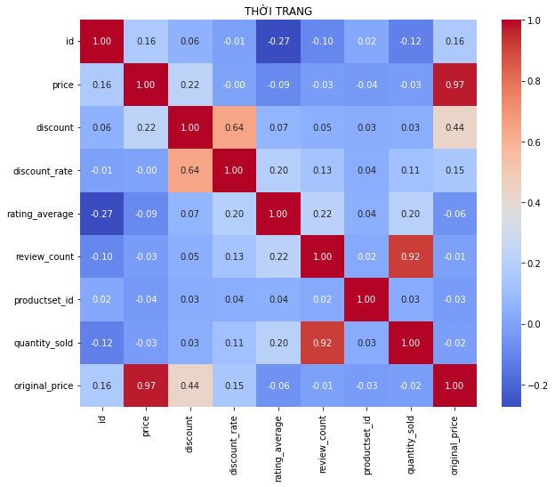

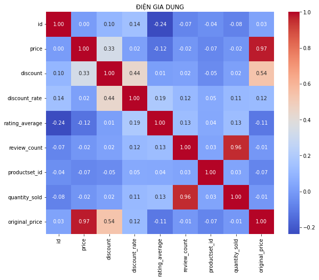

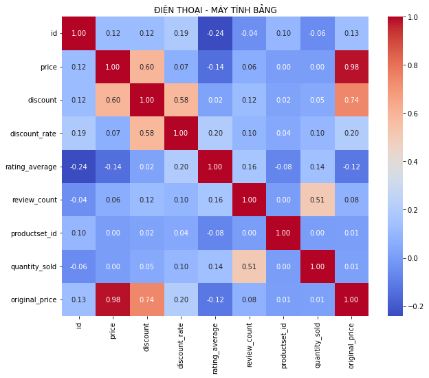

```python
dataframes = [thoitrang, dien, mobile]
titles = ["THỜI TRANG", "ĐIỆN GIA DỤNG", "ĐIỆN THOẠI - MÁY TÍNH BẢNG"]

for df, title in zip(dataframes, titles):
    corr_matrix = df.corr()
    plt.figure(figsize=(10, 8))
    sns.heatmap(corr_matrix, annot=True, fmt=".2f", cmap='coolwarm')
    plt.title(title)
    plt.show()
```

### Đánh giá:

#### Quantity Sold và Review Counts:

> Có mối tương quan mạnh trong cả 3 ngành nhưng mối tương quan này tương đối mạnh đối với thời trang nam và điện gia dụng. Điều đó chỉ ra rằng gần như các khách hàng mua các sản phẩm điện gia dụng đều để lại đánh giá sản phẩm. Đây là một điểm cần lưu ý.

# 3. Multivariate Relationship Analysis

```python
import statsmodels.api as sm
dataframes = [thoitrang, dien, mobile]
titles = ["THỜI TRANG", "ĐIỆN GIA DỤNG", "ĐIỆN THOẠI - MÁY TÍNH BẢNG"]

for df, title in zip(dataframes, titles):
    print(title)
    X = df.drop(['quantity_sold','name','brand_name'],axis = 1)
    y = df['quantity_sold']
    X = sm.add_constant(X)
    model = sm.OLS(y, X).fit()
    print(model.summary())
    print()
    print('*'*80)
    print('*'*80)
    print()
```

```
THỜI TRANG
                            OLS Regression Results
==============================================================================
Dep. Variable:          quantity_sold   R-squared:                       0.844
Model:                            OLS   Adj. R-squared:                  0.844
Method:                 Least Squares   F-statistic:                 4.202e+04
Date:                Tue, 20 Jun 2023   Prob (F-statistic):               0.00
Time:                        21:33:17   Log-Likelihood:            -2.6544e+05
No. Observations:               54280   AIC:                         5.309e+05
Df Residuals:                   54272   BIC:                         5.310e+05
Df Model:                           7
Covariance Type:            nonrobust
==================================================================================
                     coef    std err          t      P>|t|      [0.025      0.975]
----------------------------------------------------------------------------------
const              1.1895      0.992      1.199      0.231      -0.756       3.135
id             -3.118e-08   2.32e-09    -13.430      0.000   -3.57e-08   -2.66e-08
price           9.118e-07   9.51e-07      0.959      0.338   -9.52e-07    2.78e-06
discount       -2.328e-06   1.68e-06     -1.387      0.166   -5.62e-06    9.62e-07
discount_rate     -0.0318      0.017     -1.899      0.058      -0.065       0.001
rating_average    -0.0253      0.090     -0.282      0.778      -0.201       0.151
review_count       3.6095      0.007    525.053      0.000       3.596       3.623
productset_id      0.0030      0.001      4.950      0.000       0.002       0.004
original_price -1.416e-06   7.84e-07     -1.806      0.071   -2.95e-06     1.2e-07
==============================================================================
Omnibus:                   154590.240   Durbin-Watson:                   1.945
Prob(Omnibus):                  0.000   Jarque-Bera (JB):      15761080303.442
Skew:                          37.902   Prob(JB):                         0.00
Kurtosis:                    2641.758   Cond. No.                     1.83e+18
==============================================================================

Notes:
[1] Standard Errors assume that the covariance matrix of the errors is correctly specified.
[2] The smallest eigenvalue is 4.12e-16. This might indicate that there are
strong multicollinearity problems or that the design matrix is singular.


ĐIỆN GIA DỤNG
                            OLS Regression Results
==============================================================================
```

[output cut: 54 more lines]

```
rating_average    17.2358     14.183      1.215      0.225     -10.593      45.065
review_count       4.8608      0.254     19.157      0.000       4.363       5.359
productset_id      0.0525      0.214      0.245      0.806      -0.368       0.473
original_price -1.264e-05   7.19e-06     -1.758      0.079   -2.67e-05    1.47e-06
==============================================================================
Omnibus:                     2394.271   Durbin-Watson:                   1.306
Prob(Omnibus):                  0.000   Jarque-Bera (JB):          6864725.945
Skew:                          18.718   Prob(JB):                         0.00
Kurtosis:                     389.259   Cond. No.                     7.46e+16
==============================================================================

Notes:
[1] Standard Errors assume that the covariance matrix of the errors is correctly specified.
[2] The smallest eigenvalue is 7.45e-15. This might indicate that there are
strong multicollinearity problems or that the design matrix is singular.
```

### Đánh giá :

Đối với danh mục sản phẩm THỜI TRANG :

> Mô hình giải thích được khoảng 84.4% sự biến động của biến phụ thuộc 'quantity_sold'.

> Giá trị p (P>|t|) của các biến độc lập cho thấy có một số biến không có ý nghĩa thống kê, như 'price', 'discount', 'discount_rate', 'rating_average', và 'original_price'.

Đối với danh mục sản phẩm ĐIỆN GIA DỤNG :

> Mô hình giải thích được khoảng 91.4% sự biến động của biến phụ thuộc 'quantity_sold'.

> Các biến độc lập như 'id', 'price', 'discount', 'discount_rate', 'rating_average', 'review_count', 'productset_id', và 'original_price' có sự ảnh hưởng đáng kể đến số lượng sản phẩm bán được.

> Giá trị p (P>|t|) của các biến độc lập cho thấy không có biến nào không có ý nghĩa thống kê.

Đối với danh mục sản phẩm ĐIỆN THOẠI - MÁY TÍNH BẢNG :

> Mô hình chỉ giải thích được khoảng 27.3% sự biến động của biến phụ thuộc 'quantity_sold'.

> Chỉ có một số biến độc lập như 'discount_rate' và 'review_count' có ảnh hưởng đáng kể đến số lượng sản phẩm bán được.

> Các biến khác như 'id', 'price', 'discount', 'rating_average', 'productset_id', và 'original_price' không có ảnh hưởng đáng kể hoặc không có ý nghĩa thống kê.

Từ kết quả trên, ta có thể suy ra rằng mô hình hồi quy OLS phù hợp và có khả năng giải thích tốt cho các danh mục sản phẩm THỜI TRANG và ĐIỆN GIA DỤNG. Tuy nhiên, mô hình không hiệu quả cho danh mục ĐIỆN THOẠI - MÁY TÍNH BẢNG do chỉ giải thích được một phần nhỏ sự biến động của biến phụ thuộc.

## 4. Test hypothesis

> Giả thuyết discount_rate tăng số lượng mua cũng tăng

```python
# Using T-test

from scipy.stats import ttest_ind
dataframes = [thoitrang, dien, mobile]
titles = ["THỜI TRANG", "ĐIỆN GIA DỤNG", "ĐIỆN THOẠI - MÁY TÍNH BẢNG"]

for df, title in zip(dataframes, titles):
    print(title)
    high_discount = df[df['discount_rate'] > 50]['quantity_sold']
    low_discount = df[df['discount_rate'] <= 10]['quantity_sold']
    t_stat, p_value = ttest_ind(high_discount, low_discount, equal_var=False)

    print('t statistic:', t_stat)
    print('p value:', p_value)
    print("----------------------------------\n\n")
```

```
THỜI TRANG
t statistic: 3.5777900288008184
p value: 0.0004000274255854242
----------------------------------


ĐIỆN GIA DỤNG
t statistic: 2.5551496783572856
p value: 0.011630428303346745
----------------------------------


ĐIỆN THOẠI - MÁY TÍNH BẢNG
t statistic: 2.715163876756762
p value: 0.2197231394984552
----------------------------------
```

### Đánh giá

#### Thời trang nam :

> p-value (0.0004) nhỏ hơn 0.05, tức là có bằng chứng thống kê để bác bỏ giả thuyết không.

> Có thể rút ra kết luận rằng số lượng mua hàng trong nhóm có tỷ lệ giảm giá cao có thể cao hơn.

#### Điện Gia Dụng :

> p-value (0.0116) cũng nhỏ hơn 0.05, cho thấy có bằng chứng thống kê để bác bỏ giả thuyết không.

> Đối với mục Điện Gia Dụng cũng có thể kết luận số lượng mua hàng cũng có thể cao hơn trong nhóm có tỷ lệ giảm giá cao.

#### Điện Thoại - Máy Tính Bảng:

> Không có bằng chứng thống kê để bác bỏ giả thuyết không.

> CHƯA thể kết luận rằng số lượng mua hàng cũng có thể cao hơn trong nhóm có tỷ lệ giảm giá cao.

```python
import statsmodels.api as sm

mobile = mobile.dropna(subset=['discount_rate', 'quantity_sold'])

X = mobile['discount_rate']
y = mobile['quantity_sold']
X = sm.add_constant(X)  # Thêm hằng số

model = sm.OLS(y, X)
results = model.fit()

print(results.summary())
```

```
                            OLS Regression Results
==============================================================================
Dep. Variable:          quantity_sold   R-squared:                       0.010
Model:                            OLS   Adj. R-squared:                  0.009
Method:                 Least Squares   F-statistic:                     10.90
Date:                Tue, 20 Jun 2023   Prob (F-statistic):           0.000993
Time:                        21:33:17   Log-Likelihood:                -9225.8
No. Observations:                1094   AIC:                         1.846e+04
Df Residuals:                    1092   BIC:                         1.847e+04
Df Model:                           1
Covariance Type:            nonrobust
=================================================================================
                    coef    std err          t      P>|t|      [0.025      0.975]
---------------------------------------------------------------------------------
const             7.0746     44.457      0.159      0.874     -80.155      94.305
discount_rate     8.9355      2.707      3.301      0.001       3.625      14.246
==============================================================================
Omnibus:                     2233.927   Durbin-Watson:                   1.416
Prob(Omnibus):                  0.000   Jarque-Bera (JB):          3811982.518
Skew:                          16.131   Prob(JB):                         0.00
Kurtosis:                     290.377   Cond. No.                         21.7
==============================================================================

Notes:
[1] Standard Errors assume that the covariance matrix of the errors is correctly specified.
```

### Đánh giá

> Hệ số hồi quy (coef): Hệ số hồi quy của discount_rate là 8.9355. Điều này có nghĩa là khi tỷ lệ giảm giá tăng 1%, số lượng sản phẩm đã bán sẽ tăng 8.9355 đơn vị

> Dựa trên kết quả này, **chúng ta có thể kết luận rằng tỷ lệ giảm giá có mối quan hệ dương và đáng kể với số lượng sản phẩm đã bán trong danh mục Điện Thoại - Máy Tính Bảng.**

## 5. Comparison between products that are sold the most and the least

```python
thoitrang.sort_values(by = ['quantity_sold'],ascending = False)
```

|  | id | name | brand_name | price | discount | discount_rate | rating_average | review_count | productset_id | quantity_sold | original_price |
| --- | --- | --- | --- | --- | --- | --- | --- | --- | --- | --- | --- |
| 100532 | 16910398 | Combo 5 Quần Lót Nam vải cotton 2 chiều lưng C... | CITYMEN | 75000 | 25000 | 25 | 4.5 | 630 | 1479 | 5131 | 100000 |
| 100093 | 31638135 | Combo 4 quần lót nam Boxer sợi cạp 1cm sợ... | MRM Manlywear | 255000 | 85000 | 25 | 4.7 | 1183 | 1479 | 4372 | 340000 |
| 99048 | 52184516 | Combo 3 quần lót nam Boxer sợi cotton organ... | MRM Manlywear | 199000 | 86000 | 30 | 4.6 | 1194 | 1479 | 3922 | 285000 |
| 54765 | 16712370 | Áo Khoác Kaki Nam Hai Lớp Simple Cao Cấp ShopN... | N6 | 174000 | 71000 | 29 | 3.9 | 1134 | 1421 | 3883 | 245000 |
| 42608 | 14528867 | Áo Sơ Mi Nam KOJIBA Dài Tay Công Sở, Kiểu Dáng... | KOJIBA | 170000 | 0 | 0 | 4.0 | 300 | 1609 | 3604 | 170000 |
| ... | ... | ... | ... | ... | ... | ... | ... | ... | ... | ... | ... |
| 23577 | 91107325 | Áo Thun Phản Quang Nam Nữ In hình MẶt Trăng,... | VHL | 86000 | 0 | 0 | 0.0 | 0 | 1411 | 0 | 86000 |
| 23578 | 197880639 | Áo phông Still 2gether The Series BL mẫu HOT g... | OEM | 99000 | 0 | 0 | 0.0 | 0 | 1411 | 0 | 99000 |
| 23579 | 195158198 | HOT Áo Phông TOKYO GHOUL PRINT DESIGN mẫu mới ... | OEM | 105040 | 0 | 0 | 0.0 | 0 | 1411 | 0 | 105040 |
| 23580 | 105089265 | Áo thun layer 3 xẻ tà nam nữ shop FOX | OEM | 89000 | 0 | 0 | 0.0 | 0 | 1411 | 0 | 89000 |
| 101451 | 35599981 | Bộ 3 quần sịp chéo nam thông hơi | LQ luxury | 54000 | 0 | 0 | 0.0 | 0 | 1479 | 0 | 54000 |

54280 rows × 11 columns

```python
print(f"Tỉ lệ hàng không bán được ở THỜI TRANG NAM là :{round(len(thoitrang[thoitrang.quantity_sold==0])/len(thoitrang)*100,3)}%")
print()
print(f"Tỉ lệ hàng không bán được ở ĐIỆN GIA DỤNG là :{round(len(dien[dien.quantity_sold==0])/len(dien)*100,3)}%")
print()
print(f"Tỉ lệ hàng không bán được ở ĐIỆN THOẠI-MÁY TÍNH BẢNG là :{round(len(mobile[mobile.quantity_sold==0])/len(mobile)*100,3)}%")
```

```
Tỉ lệ hàng không bán được ở THỜI TRANG NAM là :72.71%

Tỉ lệ hàng không bán được ở ĐIỆN GIA DỤNG là :56.788%

Tỉ lệ hàng không bán được ở ĐIỆN THOẠI-MÁY TÍNH BẢNG là :56.947%
```

> Dựa vào danh mục bán hàng, có thể kết luận rằng mục Thời trang nam có tỷ lệ hàng không bán được cao hơn so với các mục hàng khác. Điều này cho thấy có một tỷ lệ lớn các sản phẩm trong mục này không được tiêu thụ hoặc không gặp nhu cầu của khách hàng.Mục Điện gia dụng và mục Điện thoại -Máy tính bảng cũng chiếm tỉ lệ khoảng 57%

```python
# chia top 10% bán được và không bán được đối với thời trang nam
thoitrang_sold = thoitrang.sort_values(by='quantity_sold', ascending=False).head(round(len(thoitrang) * 0.10))
thoitrang_not_sold = thoitrang[thoitrang['quantity_sold'] == 0]

# chia top 10% bán được và không bán được đối với điện gia dụng
dien_sold = dien.sort_values(by='quantity_sold', ascending=False).head(round(len(dien) * 0.10))
dien_not_sold = dien[dien['quantity_sold'] == 0]

# chia top 10% bán được và không bán được đối với điện thoại máy tính bảnhg
mobile_sold = mobile.sort_values(by='quantity_sold', ascending=False).head(round(len(mobile) * 0.10))
mobile_not_sold = mobile[mobile['quantity_sold'] == 0]
```

```
THỜI TRANG NAM
```

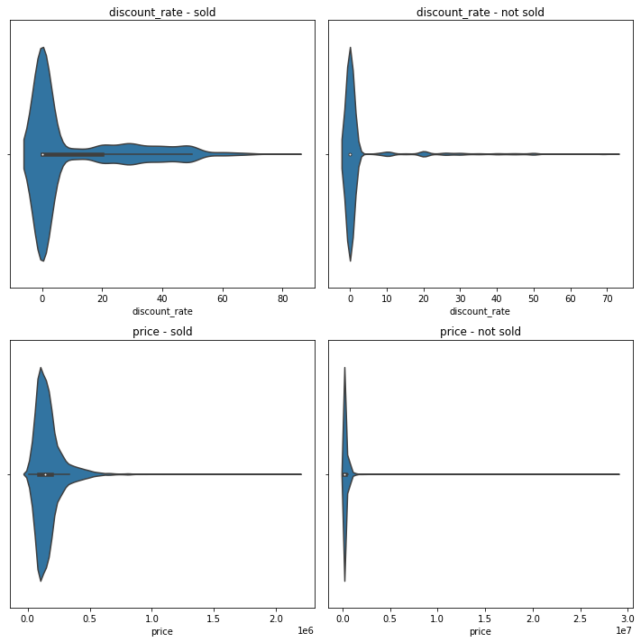

```
ĐIỆN GIA DỤNG
```

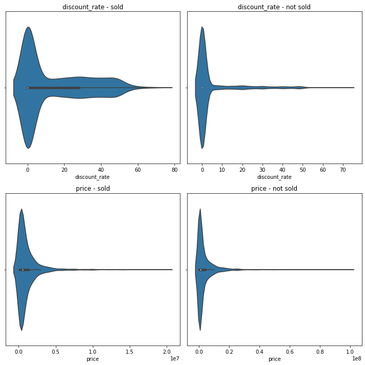

```
ĐIỆN THOẠI MÁY TÍNH BẢNG
```

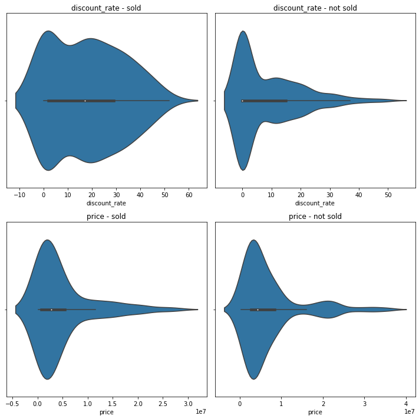

```python
def plot_data(title, sold_data, not_sold_data, variables=['discount_rate', 'price']):
    print(title.upper())

    groups = [sold_data, not_sold_data]
    group_labels = ['sold', 'not sold']

    fig, axes = plt.subplots(nrows=2, ncols=2, figsize=(10, 10))

    for i, variable in enumerate(variables):
        for j, group in enumerate(groups):
            sns.violinplot(data=group, x=variable, ax=axes[i, j])
            axes[i, j].set_title(f'{variable} - {group_labels[j]}')

    plt.tight_layout()
    plt.show()

plot_data("Thời trang nam", thoitrang_sold, thoitrang_not_sold)
print('*'*90)
plot_data("Điện gia dụng", dien_sold, dien_not_sold)
print('*'*90)
plot_data("Điện thoại máy tính bảng", mobile_sold, mobile_not_sold)
```

### Đánh giá:

> Dựa trên dữ liệu trên với cả 3 Mục THỜI TRANG NAM, ĐIỆN GIA DỤNG, ĐIỆN THOẠI MÁY TÍNH BẢNG có thể thấy mối quan hệ mật thiết giữa số lượng bán được hàng so với tỉ lệ giảm giá. Đặc biệt với Mục ĐIỆN THOẠI-MÁY TÍNH BẢNG với top 10% sản phẩm bán chạy nhất, có phạm vi của tỉ lệ giảm giá rất rộng và đồng đều từ 0 ~30% và ít dần đến 60%. Điều này cho thấy việc giảm giá đã kích thích rất tốt đến hành vi mua hàng của khách.

> Với các biểu đồ về cột giá sản phẩm (price) có vẻ giá bán của sản phẩm có thể ảnh hưởng đến khả năng bán hàng. Các sản phẩm với giá cao hơn dường như khó bán hơn so với những sản phẩm có giá thấp hơn.(Cả 3 danh mục đều giống nhau)

```
THỜI TRANG NAM
```

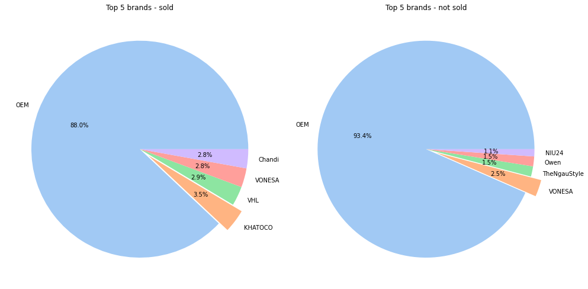

```
ĐIỆN GIA DỤNG
```

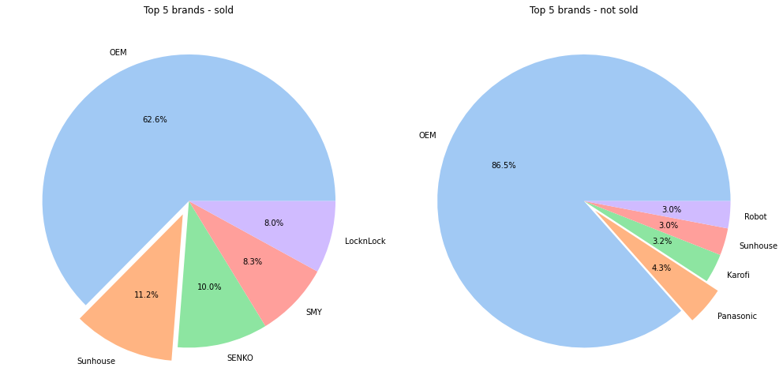

```
ĐIỆN THOẠI MÁY TÍNH BẢNG
```

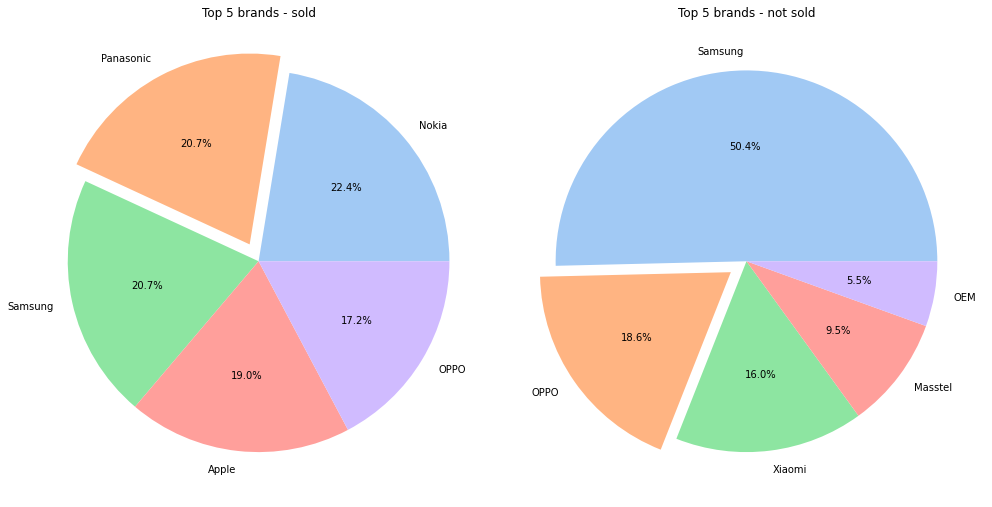

```python
import matplotlib.pyplot as plt
import seaborn as sns

def plot_pie(title, sold_data, not_sold_data, col='brand_name'):
    print(title.upper())

    fig, axes = plt.subplots(nrows=1, ncols=2, figsize=(14, 7))

    top_5_sold = sold_data[col].value_counts().head(5)
    top_5_not_sold = not_sold_data[col].value_counts().head(5)

    explode = [0.1 if i == 1 else 0 for i in range(5)]
    palette_color = sns.color_palette('pastel')

    axes[0].pie(top_5_sold.values, labels=top_5_sold.index, autopct='%1.1f%%', explode=explode, colors=palette_color)
    axes[0].set_title('Top 5 brands - sold')

    axes[1].pie(top_5_not_sold.values, labels=top_5_not_sold.index, autopct='%1.1f%%', explode=explode, colors=palette_color)
    axes[1].set_title('Top 5 brands - not sold')

    plt.tight_layout()
    plt.show()


plot_pie("Thời trang nam", thoitrang_sold, thoitrang_not_sold)
plot_pie("Điện gia dụng", dien_sold, dien_not_sold)
plot_pie("Điện thoại máy tính bảng", mobile_sold, mobile_not_sold)
```

### Đánh giá

> Đối với danh mục Thời Trang Nam và Điện Gia Dụng, OEM chiếm tỉ lệ khá lớn trong cả top sold 10% và not sold.

> Đối với Mục Điện thoại máy tính bảng, top 5 brand có số lượng bán nhiều nhất là Panasonic, Samsung, Apple,Oppo và Nokia. Ngược lại, Các brand có số lượng không bán được nhiều nhất là Samsung (50.4%) Oppo, Xiaomi. Masstel và OEM. Điều này cũng cho thấy được bán được sản phẩm hay không cũng phụ thuộc vào thương hiệu của từng sản phẩm

> Lí do Panasonic bán rất chạy trong danh mục điện thoại máy tính là các dòng sản phẩm của Panasonic chủ yếu đến từ điện thoại bàn và giá rất rẻ so với các điện thoại khác. Cả về giá gốc và discount rate cũng tốt hơn rất nhiều so với các brand còn lại, điều này đã được chứng minh bởi những phân tích bên trên :
> - Giá gốc nhỏ hơn > quantity sold lớn hơn
> - Discount rate lớn hơn > quantity sold lớn hơn

## 6. Compare the differences between the products with the highest and lowest rates

```python
tt_rate = thoitrang[thoitrang.rating_average !=0.0].sort_values(by = ['rating_average'],ascending = False)
dien_rate = dien[dien.rating_average !=0.0].sort_values(by = ['rating_average'],ascending = False)
mobile_rate = mobile[mobile.rating_average !=0.0].sort_values(by = ['rating_average'],ascending = False)

def split_dataframe(df):
    top_10percent_index = int(len(df) * 0.1)
    bottom_10percent_index = len(df) - top_10percent_index

    df_head = df.iloc[:top_10percent_index]
    df_tail = df.iloc[bottom_10percent_index:]

    return df_head, df_tail

thoitrang_head, thoitrang_tail = split_dataframe(tt_rate)
dien_head, dien_tail = split_dataframe(dien_rate)
mobile_head, mobile_tail = split_dataframe(mobile_rate)
```

```
THỜI TRANG NAM
```

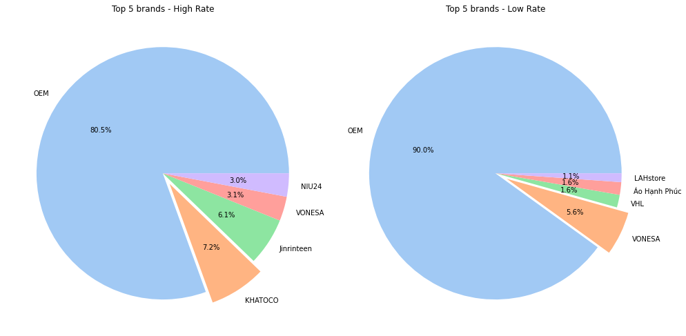

```
ĐIỆN GIA DỤNG
```

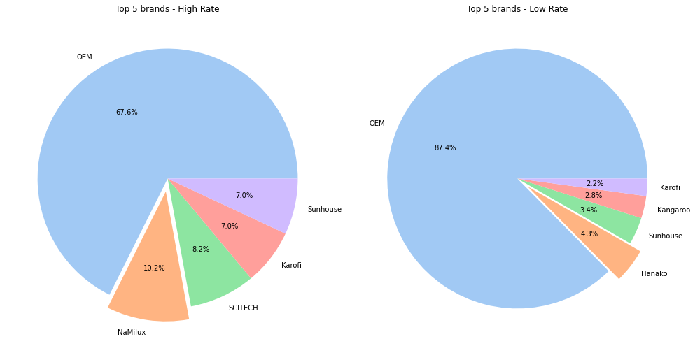

```
ĐIỆN THOẠI MÁY TÍNH BẢNG
```

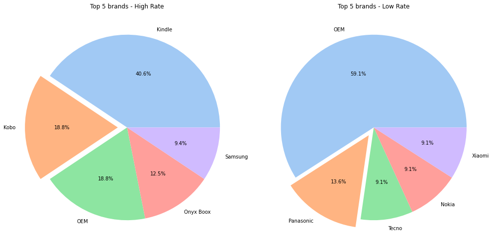

```python
import matplotlib.pyplot as plt
import seaborn as sns

def plot_pie(title, sold_data, not_sold_data, col='brand_name'):
    print(title.upper())

    fig, axes = plt.subplots(nrows=1, ncols=2, figsize=(14, 7))

    top_5_sold = sold_data[col].value_counts().head(5)
    top_5_not_sold = not_sold_data[col].value_counts().head(5)

    explode = [0.1 if i == 1 else 0 for i in range(5)]
    palette_color = sns.color_palette('pastel')

    axes[0].pie(top_5_sold.values, labels=top_5_sold.index, autopct='%1.1f%%', explode=explode, colors=palette_color)
    axes[0].set_title('Top 5 brands - High Rate')

    axes[1].pie(top_5_not_sold.values, labels=top_5_not_sold.index, autopct='%1.1f%%', explode=explode, colors=palette_color)
    axes[1].set_title('Top 5 brands - Low Rate')

    plt.tight_layout()
    plt.show()


plot_pie("Thời trang nam", thoitrang_head, thoitrang_tail)
plot_pie("Điện gia dụng", dien_head, dien_tail)
plot_pie("Điện thoại máy tính bảng", mobile_head, mobile_tail)
```

### Đánh giá:

> Với danh mục Thời trang và Điện gia dụng, sản phẩm từ OEM chiếm rất lớn nên chiếm số lượng lớn ở 2 mục high và low rating, Data bị biased, khó thể có đánh giá được nhiều.

> Với danh mục Điện thoại máy tính bảng có thể thấy rằng các thương hiệu được đánh giá tốt phần lớn là máy đọc sách và máy tính bảng (Kindle, Kobo và Onyx Boox) , các sản phẩm của samsung tất cả đều là máy tính bảng.

```
THỜI TRANG NAM
```

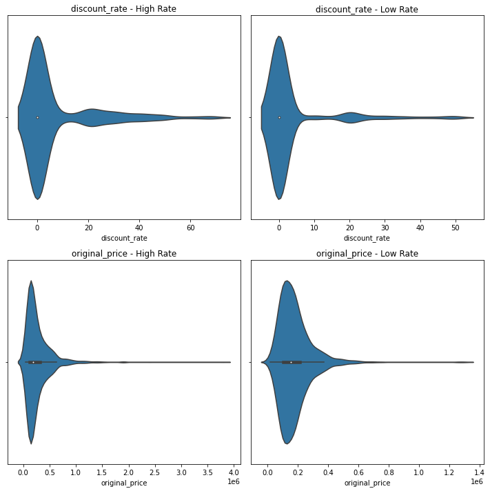

```
ĐIỆN GIA DỤNG
```

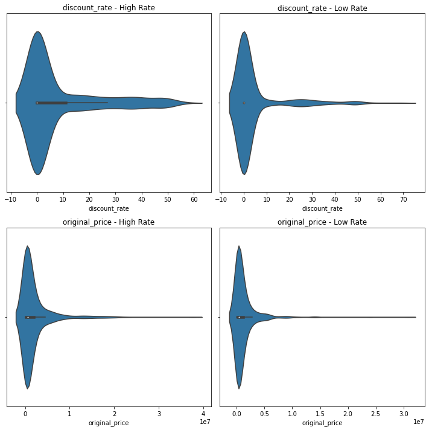

```
ĐIỆN THOẠI MÁY TÍNH BẢNG
```

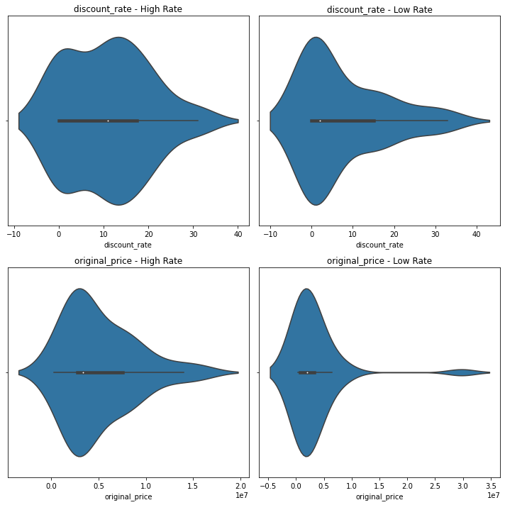

```python
def plot_data(title, high_data, low_data, variables=['discount_rate', 'original_price']):
    print(title.upper())

    groups = [high_data, low_data]
    group_labels = ['High Rate', 'Low Rate']

    fig, axes = plt.subplots(nrows=2, ncols=2, figsize=(10, 10))

    for i, variable in enumerate(variables):
        for j, group in enumerate(groups):
            sns.violinplot(data=group, x=variable, ax=axes[i, j])
            axes[i, j].set_title(f'{variable} - {group_labels[j]}')

    plt.tight_layout()
    plt.show()

plot_data("Thời trang nam", thoitrang_head, thoitrang_tail)
plot_data("Điện gia dụng", dien_head, dien_tail)
plot_data("Điện thoại máy tính bảng", mobile_head, mobile_tail)
```

### Đánh giá:

> Phần lớn các sản phẩm có giá gốc cao hơn được đánh giá tốt hơn. Điều này có vẻ đúng vì giá gốc sản phẩm cao đồng nghĩa với chất lượng sản phẩm tốt hơn theo đó trải nghiệm của khách hàng cũng tốt hơn

> Discount Rate cũng khá giống với Phần top các sản phẩm bán được và top các sản phẩm không bán được 3 Mục THỜI TRANG NAM, ĐIỆN GIA DỤNG, ĐIỆN THOẠI MÁY TÍNH BẢNG có thể thấy mối quan hệ mật thiết giữa tỉ lệ điểm đánh giá với tỉ lệ giảm giá. Đặc biệt với Mục ĐIỆN THOẠI-MÁY TÍNH BẢNG với top 10% sản phẩm có rating tốt nhất, phạm vi của tỉ lệ giảm giá rộng và trải rộng hơn về phía 15%, cao hơn nhóm có rating thấp.

## 7. Check skewness of features

```python
import warnings
warnings.filterwarnings('ignore')

dfs = [thoitrang,dien,mobile]
names = ['Thời Trang Nam',"Điện Gia Dụng","Điện thoại máy tính bảng"]

for df,name in zip(dfs,names):
    print(name,":")
    display(df.skew())
    print('-'*40)
```

```
Thời Trang Nam :
```

```
id                -0.235494
price             20.285261
discount          12.465905
discount_rate      3.081899
rating_average     1.900988
review_count      31.453869
productset_id      3.318318
quantity_sold     30.662760
original_price    17.350455
dtype: float64
```

```
----------------------------------------
Điện Gia Dụng :
```

```
id                -0.167186
price              6.435601
discount          14.921571
discount_rate      2.071434
rating_average     1.118984
review_count      49.701217
productset_id      0.088980
quantity_sold     42.457644
original_price     6.453914
dtype: float64
```

```
----------------------------------------
Điện thoại máy tính bảng :
```

```
id                -1.194644
price              2.157242
discount           3.386797
discount_rate      0.989109
rating_average     0.805878
review_count      18.978514
productset_id    -19.038744
quantity_sold     16.285993
original_price     2.209000
dtype: float64
```

> Dựa trên các giá trị trên, ta có thể thấy rằng hầu hết các cột trong tất cả ba DataFrame đều có sự lệch trong phân phối của chúng

> Một số rất lớn như 'price', 'discount', 'review_count' và 'quantity_sold' trong DataFrame "Thời Trang Nam", cho thấy dữ liệu rất lệch về phía phải.

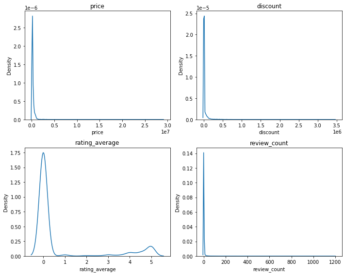

```python
# show some features of thoitrang in kdeplot

fig, axes = plt.subplots(nrows=2, ncols=2, figsize=(10, 8))


for i, feature in enumerate(['price','discount','rating_average','review_count']):
    row = i // 2
    col = i % 2
    sns.kdeplot(thoitrang[feature], ax=axes[row, col])
    axes[row, col].set_title(feature)


plt.tight_layout()
plt.show()
```